# Brain RNA-Seq Differential Expression Analysis

Wei Wei

11/18/2016

# Part A. RNA-Seq Differential Gene Expression Analysis

### 1. Synopsis

Genomics is one the four major generators of “Big Data” in 2016, together with astronomy, Twitter, and Youtube [[ 1 ]](http://journals.plos.org/plosbiology/article?id=10.1371/journal.pbio.1002195). With ever decreasing cost using Next-Generation Sequencing (NGS), the amount of sequencing data deposited in open-access databases such as the Sequence Read Archive (SRA) at National Center for Biotechnology Information (NCBI) has increased dramatically. As of November 2016, SRA holds 4 petabases of sequence data, that is the number 4, followed by 15 zeros. With the amount of sequence data generated world-wide expected to double every 7-12 months, we are entering the era of “genomical” data.

In this report, differetially gene expression analysis was carried out using RNA-Seq run dataset published in Jaffe et al., 2015 [[ 2 ]](http://www.ncbi.nlm.nih.gov/pmc/articles/PMC4281298/). The paired-end reads of 6 fetal and 6 adult brains were downloaded from the NCBI Sequence Read Archive. Part A of the report describes the results of the differential gene expression analysis carried out using command line tools and Bioconductor/R/Rstudio that are free and open-source software. Part B provides the documentation of the reproducible research.

### 2. RNA-Seq run data download and reads alignment

The complete set of 6 fetal and 6 adult brain RNA-seq data was downloaded from NCBI Sequence Read Archive on the command line. Of the 2 runs available from each sample, the runs with the prefix SRR1554 was selected due to the agreeable file sizes (average: 10.9 GB). Each of the sra files, containing on average 109 million paired-end reads, were converted to two paired fastq files. The fastq files were then aligned to the human genome using the command line tool hisat2 and an Ensembl GRCh38.85 index.

Examining alignment results using samtools flagstat showed that above 99.7% of the reads are mapped in each alignment sam files.

### 3. Mapped reads quality control

There are no differences in the averages of per sequence qualities (37 fetal vs 37 adult). However, there is the general trend of decreasing averages of per base position qualities in both groups from base position 1 to 100. The medians of the qualities at base position 100 for all runs are above 26, which indicates high-quality.

A summary table on the alignment and quality control is shown below.

| run | group | age | race | sex | RIN | reads_total | reads_mapped | perc_map | QUAL | GC |
| --- | --- | --- | --- | --- | --- | --- | --- | --- | --- | --- |
| SRR1554537 | fetal | -0.38 | AA | female | 9.6 | 129226233 | 128954910 | 99.79 | 37 | 48 |
| SRR1554538 | fetal | -0.40 | AA | female | 6.4 | 156218674 | 155901551 | 99.80 | 37 | 47 |
| SRR1554541 | fetal | -0.38 | AA | male | 5.7 | 157054456 | 156759454 | 99.81 | 37 | 46 |
| SRR1554566 | fetal | -0.50 | HISP | male | 8.3 | 121769844 | 121541284 | 99.81 | 37 | 49 |
| SRR1554567 | fetal | -0.40 | AA | male | 8.6 | 139153209 | 138889436 | 99.81 | 37 | 46 |
| SRR1554568 | fetal | -0.50 | AA | male | 8.0 | 108658312 | 108435198 | 99.79 | 37 | 47 |
| SRR1554534 | adult | 40.42 | AA | male | 8.4 | 67612060 | 67457460 | 99.77 | 37 | 51 |
| SRR1554535 | adult | 41.58 | AA | male | 8.7 | 94243133 | 94014932 | 99.76 | 37 | 48 |
| SRR1554536 | adult | 44.17 | AA | female | 5.3 | 50209014 | 50141254 | 99.87 | 37 | 46 |
| SRR1554539 | adult | 36.50 | AA | female | 9.0 | 78324331 | 78146767 | 99.77 | 37 | 48 |
| SRR1554556 | adult | 36.98 | AA | male | 8.5 | 113508360 | 113298932 | 99.82 | 37 | 48 |
| SRR1554561 | adult | 43.88 | AA | male | 8.7 | 93202926 | 92985771 | 99.77 | 37 | 52 |

### 4. Feature counts

The numbers of reads mapped per known gene were summarized using the command line tool featureCounts. Homo_sapiens.GRCh38.85.gtf was used as the reference annotation file. In addition to using the appropriate gtf file, paired-end reads were summarized as fragments (featureCounts flag “-p”), and only those fragments that have both ends mapped were counted (featureCounts flag “-B”).

The numbers of fragments assigned to the gene features were un-normalized, raw counts.

### 5. Exploratory analysis and differential expression analysis

The feature counts data was loaded into R for exploratory analysis and differential gene expression analysis with Bioconductor.

#### 5.1. A DESeqDataSet object with gene expression data in un-normalized counts

To facilitate downstream data manipulation, a RangedSummerizedExperiment object, “brain_rse”, was generated in Bioconductor. The colData(brain_rse) contains the 12 brain sample information; the rowRanges(brain_rse) contains the ranges of features; and the assay(brain_rse, 1) contains the raw (un-normalized) gene expression data in counts.

This RangedSummerizedExperiment object, brain_rse, was converted to a DESeqDataSet object, ddsMat, in DESeq2. Initially, the design matrix is assigned as `~ group`. As written, the design matrix `~ group` tests the null hypothesis that there are no differences in gene expression counts between the two discrete levels in the “group” variable, i.e., “adult” and “fetal”.

```
##                 SRR1554537 SRR1554538 SRR1554541 SRR1554566 SRR1554567 SRR1554568
## ENSG00000000003       2653       3864       2643       2949       3320       2384
## ENSG00000000005          2          6         14          2          5          6
## ENSG00000000419       1782       2015       1985       2204       2290       1742
##                 SRR1554534 SRR1554535 SRR1554536 SRR1554539 SRR1554556 SRR1554561
## ENSG00000000003        244        632        455        417        669        228
## ENSG00000000005         22         22          6          6          1          6
## ENSG00000000419        758       1838        346       1248       1639        896
```

#### 5.2. Exploratory analysis with DESeq2 - Bioconductor

The statistical distributions of gene expression levels were plotted for all 12 samples using boxplot, see left panel below. It was apparent that the ranges of gene expression levels vary greatly among samples. The expression levels were thus transformed using the regularized log transformation of the DESeq2 package. The rlog-transformed gene expression data were replotted in the right panel below. All samples have similar statistical distribution after the rlog-transformation.

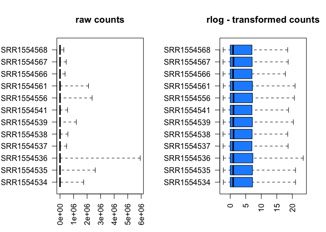

Principal component analysis (PCA) was applied to the rlog-transformed gene expression data. As seen on the PCA bi-plot below, the 1st principal component, PC1, which explains ~85% of the variance, correlates perfectly with the “fetal”/“adult”-“group” status. However, the 2nd principal component, PC2, does not correlate well with any known variables in the sample info table, e.g., “sex”, “race”, “reads_total”, “reads_mapped”, or “coverage” (data analysis not shown).

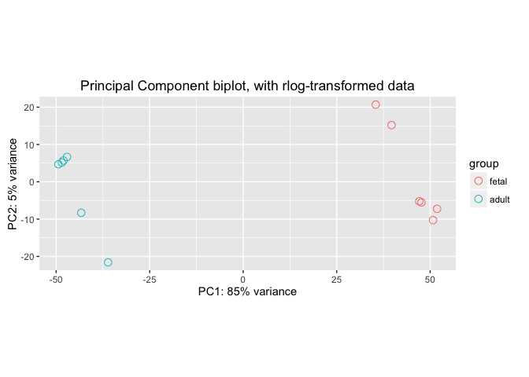

#### 5.3. Removing hidden batch effects using the SVA package

In order to remove hidden batch effects, two surrogate variables, SV1 and SV2, were thus generated using the sva package.

```
## Number of significant surrogate variables is:  2
## Iteration (out of 5 ):1  2  3  4  5
```

The DESeqDataSet object, ddsMat, was modified to ddssva with the design matrix `~ SV1 + SV2 + group`. As written, the design matrix `~ SV1 + SV2 + group` tests the null hypothesis that there are no differences in gene expression counts between the two discrete levels in the “group” variable, “adult” and “fetal”, after removing the hidden batch effects resulting from the two surrogate variables, SV1 and SV2. Removing these hidden batch effects increases the sensitivity in detecting differences in gene expression counts due to the “group” variable.

#### 5.4. Statistical analysis with DESeq2 - Bioconductor

Statistical analysis was performed in R Bioconductor to detect genes that are differentially expressed using the DESeq2 package. Analysis shows that 18583 genes out of 58051 known genes (32.01%) are differentially expressed in adult vs in fetal brain cortex, with the False Discovery Rate (FDR) set at 5%. Among the 18583 statistically significant DE genes, 9457 are up-regulated and 9126 are down-regulated in adult brains. This analysis demonstrates the dramatically different gene expression patterns in adult vs in fetal brains.

#### 5.5. Conversion of Ensembl id to Entrez id

The statistical analysis yielded statistical information of genes listed in Ensembl ids. To facilitate downstream analysis, Ensembl ids were converted to Entrez ids using the convertIDs function. Alternatively, the `biomaRt` service can be used for the same purpose.

After converting Ensembl gene id to Entrez id, of the 58051 Ensembl genes, 24862 were mapped to Entrez ids, while 33189 did not. There were 7 duplicate Entrez ids after conversion.

From the RNA-Seq statistical analysis, 20508 genes have Entrez ids and FDR padj values. Of these 20508 genes, 13020 are differentially expressed between fetal and adult brains (padj < 0.05). However, 14570 genes that have FDR padj values do not have Entrez ids. Of these 14570 genes, 5563 were differentially expressed between fetal and adult brains (padj < 0.05).

```
## log2 fold change (MAP): group adult vs fetal
## Wald test p-value: group adult vs fetal
## DataFrame with 3 rows and 8 columns
##                   baseMean log2FoldChange     lfcSE       stat       pvalue         padj
##                  <numeric>      <numeric> <numeric>  <numeric>    <numeric>    <numeric>
## ENSG00000000003 1342.76409     -1.6502232 0.2512891 -6.5670311 5.132834e-11 3.264377e-10
## ENSG00000000005   10.35028      2.0035744 0.6803972  2.9447130 3.232543e-03 7.533295e-03
## ENSG00000000419 1399.51675      0.1468805 0.1748122  0.8402189 4.007856e-01 4.983255e-01
##                      symbol    entrezid
##                 <character> <character>
## ENSG00000000003      TSPAN6        7105
## ENSG00000000005        TNMD       64102
## ENSG00000000419        DPM1        8813
```

#### 5.6. Diagnostic analysis

##### 5.6.1 MA-plot

In the MA-plot below, the means of normalized counts were plotted against the log-fold change. Among the statistically significant DE genes (padj < 0.05, red), OPALIN (blue) has the largest log2-fold increase; while IGF2B1 (green) has the largest log2-fold decrease in the “adult” group compared to the “fetal” group.

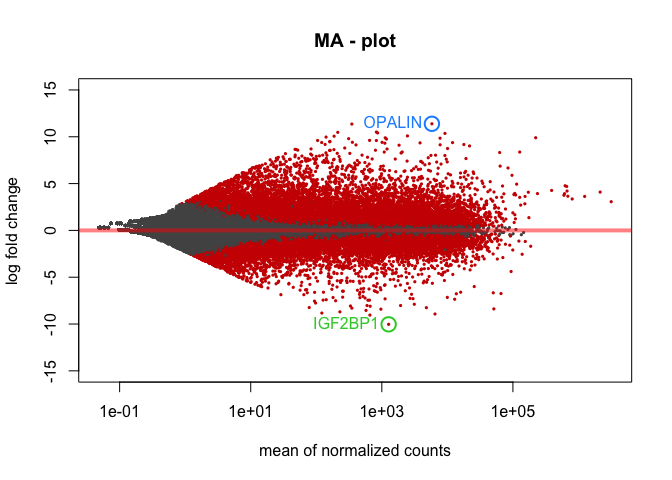

The DESeq2 package moderates the log2-fold changes from genes with low counts and highly variable counts. This plot shows that only genes with a large average normalized count contain sufficient information to yield a significant call.

##### 5.6.2. Histogram of adjusted p-value

The histogram of the adjusted p-value shows that a large number of genes have very small adjusted p-values. This observation leads to the intuition that many of the very small adjusted p-values are instances of false null hypotheses.

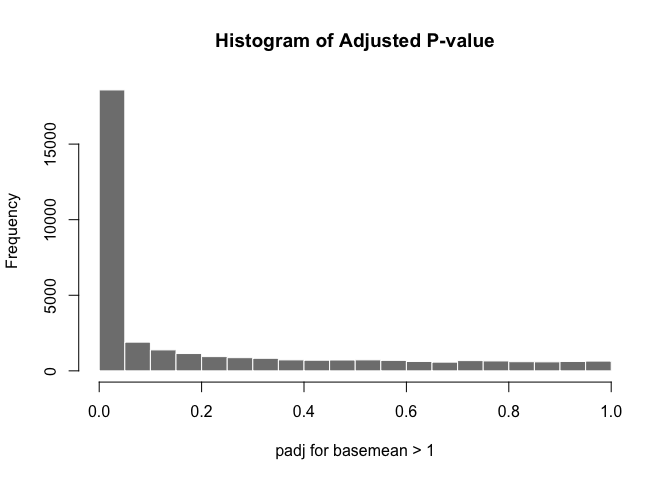

##### 5.6.3 Volcano plot

The Volcano plot shows that there are large number of genes in this DE analysis that show statistically significant *and* large magnitude changes.

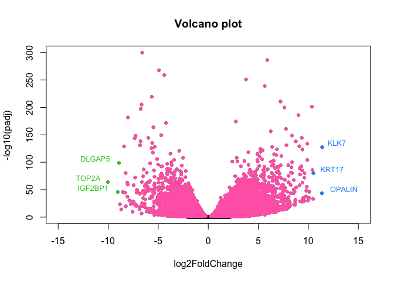

### 6. Gene set analysis

Using the H3K4me3 CHIP-Seq data provided by the Roadmap Epigenomics project, the association of the H3K4me3 markers and the promoter regions of the differentially expressed sets of genes in fetal and adult brains was examined. It was found that fetal brain-specific H3K4me3 markers preferentially overlap with the fetal brain DE gene promoters; and adult brain-specific H3K4me3 markers preferentially overlap with the adult brain DE gene promoters. As control, liver-specific H3K4me3 markers overlap comparably with either DE gene promoters.

#### 6.1. Genomic ranges of DE gene promoters and H3K4me3 peaks

The promoter regions, defined in this report as 2000 bp upstream and 1000 bp downstream of transcriptional start site, were retrieved using the `TxDb.Hsapiens.UCSC.hg19.knownGene` package, for fetal DE genes and adult DE genes, respectively.

H3K4me3 peaks ranges in the fetal brain (“AH30471”), adult brain (“AH30413”), and adult liver (“AH30367”) were retrieved via AnnotationHub.

#### 6.2. Counting overlaps of H3K4me3 peaks and promoter regions

Upon initial examination of the H3K4me3 genomic ranges from fetal brain (47536 ranges), adult brain (75912 ranges), and liver (92123 ranges), it was apparent that a large number of these H3K4me3 genomic ranges overlap or are shared among the 3 types of tissues. For example, fetal brain and adult brain have 41676 H3K4me3 genomic ranges that overlap. This should not be surprising. H3K4me3 is known to preferentially mark the promoters of actively transcribed genes. Even though fetal brain, adult brain, and liver are distinct types of tissue, there are a large number of house-keeping genes expressed in all cell types. Furthermore, even though genes were found to be differentially expressed in fetal brain vs in adult brain, down-regulation of gene expression does not equal to no expression.

To identify H3K4me3 ranges that are truly unique to each tissue type, H3K4me3 genomic ranges that are shared between the three tissue types are thus filtered out. It was found that 5192 H3K4me3 ranges were specific to fetal brain, 41818 to adult brain, and 57470 to liver.

Of the 5192 fetal brain-specific H3K4me3 ranges, 239 overlap with fetal DE gene promoter regions and 79 overlap with adult DE gene promoter regions.

Of the 41818 adult brain-specific H3K4me3 ranges, 1189 overlap with fetal DE gene promoter regions and 3041 overlap with adult DE gene promoter regions.

Of the 57470 liver-specific H3K4me3 ranges, 1025 overlap with fetal DE gene promoter regions and 1303 overlap with adult DE promoter regions.

Thus, it appears that fetal brain-specific H3K4me3 markers preferentially overlap with fetal DE gene promoter regions, and adult brain-specific H3K4me3 markers preferentially overlap with adult DE gene promoter regions, while liver-specific H3K4me3 markers overlap comparably with either DE gene promoters.

Fisher’s exact test was carried out to test the association of fetal/adult-specific H3K4me3 ranges with fetal/adult promoter regions. The null hypothesis is that there is no association of fetal/adult-specific H3K4me3 ranges with fetal/adult promoter regions. With the p-value < 0.05, we can reject the null hypothesis.

Number of H3K4me3 overlapping DE promoter regions

|  | fetal_DE | adult_DE |
| --- | --- | --- |
| fetal unique H3K4me3 | 239 | 79 |
| adult unique H3K4me3 | 1189 | 3041 |

```
##
##  Fisher's Exact Test for Count Data
##
## data:  mtx
## p-value < 2.2e-16
## alternative hypothesis: true odds ratio is not equal to 1
## 95 percent confidence interval:
##   5.915938 10.196663
## sample estimates:
## odds ratio
##   7.732537
```

# Part B. RNA-Seq Analysis Pipeline Documentation

### 1. Synopsis

Reproducible research is the idea that data analyses, and more generally, scientific claims, are published with their data and software code so that others may verify the findings and build upon them [[ 3 ]](https://www.ncbi.nlm.nih.gov/pmc/articles/PMC3383002/). One of the major issues compounding published biological research is the lack of reproducibility. With many steps in a typical genome data analysis pipeline, it is crucial to document all the steps in detail to ensure reproducibility.

Part B of this brain differential gene expression analysis thus provides documentation of all the steps in the analysis pipeline.

### 2. RNA-Seq data

#### 2.1. Download of 6 fetal and 6 adult brain RNA-Seq data in sra format from NCBI

The 6 fetal and 6 adult brain RNA-Seq dataset is part of the dataset published in Jaffe et al. 2015 [[ 2 ]](http://www.ncbi.nlm.nih.gov/pmc/articles/PMC4281298/).

Software: wget - Unix command line

```
wget ftp://ftp-trace.ncbi.nih.gov/sra/sra-instant/reads\
                  /ByRun/sra/SRR/SRR155/SRR1554537/SRR1554537.sra
```

RNA-Seq runs SRR1554538.sra, SRR1554541.sra, SRR1554566.sra, SRR1554567.sra, SRR1554568.sra, SRR1554535.sra, SRR1554536.sra, SRR1554539.sra, SRR1554556.sra, SRR1554561.sra, and SRR1554534.sra were downloaded using identical syntax.

#### 2.2. Conversion of the RNA-Seq data from sra format to fastq format

Software: fastq-dump (SRA Toolkit) - Unix command line

```
fastq-dump --outdir ../../gen_data --gzip --skip-technical --readids \
            --dumpbase --split-files --clip ./*.sra | gunzip *.fastq.gz
```

#### 2.3. Download of RNA-Seq meta-data from NCBI via the web interface

Software: web interface, “RunInfo Table” clickable links

`https://www.ncbi.nlm.nih.gov/Traces/study/?acc=SRR1554537&go=go`

Meta-data for RNA-Seq runs SRR1554538, SRR1554541, SRR1554566, SRR1554567, SRR1554568, SRR1554535, SRR1554536, SRR1554539, SRR1554556, SRR1554561, and SRR1554534 were downloaded in the same manner.

#### 2.4. Merged meta-data table with info on the 12 RNA-Seq runs

Software: Unix command line

```
cat SRR155*.txt | sed -n '1p' | cut -f2- > header.txt
cat SRR155*.txt | grep "RNA-Seq" > body.txt
cat header.txt body.txt > meta_all.txt
cat meta_all.txt | cut -f20,22,26,32,33 > meta_sm.txt
```

### 3. Reads alignment

#### 3.1. The GRCh38 index file hg38_tran

Software: wget - Unix command line

```
wget ftp://ftp.ccb.jhu.edu/pub/infphilo/hisat2/data/hg38_tran.tar.gz
gunzip grch38_tran.tar.gz
tar -xvf grch38_tran.tar
```

#### 3.2. Alignment with hisat2

Software: hisat2 - Unix command line

```
hisat2 -x ../ht2_idx_np/grch38_tran/genome_tran \
      -1 ../fastq/SRR1554537_1.fastq -2 ../fastq/SRR1554537_2.fastq -S SRR1554537.sam
```

Alignment files in sam format were generated for RNA-Seq runs SRR1554538, SRR1554541, SRR1554566, SRR1554567, SRR1554568, SRR1554535, SRR1554536, SRR1554539, SRR1554556, SRR1554561, and SRR1554534 using identical syntax.

#### 3.3 Meta-data updated with alignment info

```r
# revert to 'eval=F' when done
rm(list=ls())

meta <- read.table("./data/meta_sm.txt", header=T, sep="\t")
colnames(meta) <- c("RIN", "run", "age", "race", "sex")
meta$group <- "fetal"
meta[meta$age > 0, ]$group <- "adult"
meta$group <- relevel(as.factor(meta$group), ref="fetal")

meta$reads_total <- c(67612060, 94243133, 50209014, 129226233, 156218674, 78324331,
                      157054456, 113508360, 93202926, 121769844, 139153209, 108658312)
meta$reads_mapped <- c(67457460, 94014932, 50141254, 128954910, 155901551, 78146767,
                       156759454, 113298932, 92985771, 121541284, 138889436, 108435198)
meta$perc_map <- round(meta$reads_mapped / meta$reads_total * 100, 2)
reads_total_avg <- mean(meta$reads_total) / 1e6 # 109 M
```

### 4. Mapped reads quality control

#### 4.1. FastQC

Software: FastQC - GUI via Unix command line

```
fastqc
```

SRR1554537.sam, SRR1554538.sam, SRR1554541.sam, SRR1554566.sam, SRR1554567.sam, SRR1554568.sam,  
SRR1554535.sam, SRR1554536.sam, SRR1554539.sam, SRR1554556.sam, SRR1554561.sam, SRR1554534.sam  
were selected in the FastQC GUI and the results saved.

#### 4.2. Meta-data updated with quality control info

Software: R/Rstudio

```r
meta$reads_length <- 100
meta$QUAL <- 37
meta$GC <- c(51, 48, 46, 48, 47, 48, 46, 48, 52, 49, 46, 47)
```

### 5. Feature counts

#### 5.1. featureCounts

Software: featureCounts - Unix command line

```
featureCounts -T 6 -p -B -t exon -g gene_id \
      -a ./gtf/Homo_sapiens.GRCh38.85.gtf -o ./fc/one_batch.fc.txt ./align/*.sam
```

#### 5.2. Meta-data updated with feature counts info

Software: Bioconductor/R/Rstudio

```r
library(data.table)
library(dplyr)

meta <- as.data.table(meta)
fc <- fread("./data/one_batch.fc.txt", skip=1L) # unix command on 1st line
fc.sum <- fread("./data/one_batch.fc.txt.summary")
setkey(fc, Geneid)

# simplify column names
colnames(fc) <- gsub('\\./align/(.+)\\.sam', '\\1', colnames(fc))
colnames(fc.sum) <- gsub('\\./align/(.+)\\.sam', '\\1', colnames(fc.sum))

# merge featureCounts summary info into meta-data
fc.sum <- fc.sum[1:5, ]
fc.sum.t <- t(fc.sum[, 2:13, with=F])
fc.sum.t <- data.frame(run=colnames(fc.sum)[-1], fc.sum.t)
names(fc.sum.t) <- c("run", fc.sum$Status)
fc.sum.t <- data.table(fc.sum.t)

setkey(meta, run); setkey(fc.sum.t, run)
meta_qc_fc <- meta[fc.sum.t]
meta_qc_fc$perc_assigned <- round((meta_qc_fc$Assigned / meta_qc_fc$reads_mapped) * 100)
meta_qc_fc$coverage <- round(meta_qc_fc$reads_length *
                                   as.numeric(meta_qc_fc$reads_total) / (sum(fc$Length)))

fc <- fc[, c(1, 6, 7:18), with=F]
setkey(fc, Geneid)
meta <- meta_qc_fc
setkey(meta, run)
rownames(meta) <- meta$run

fetal <- meta[meta$group == "fetal", ]
adult <- meta[meta$group == "adult", ]
t.test(fetal$reads_total, adult$reads_total, alternative="two.sided")
t.test(fetal$reads_mapped, adult$reads_mapped, alternative="two.sided")
```

```r
library(knitr)
meta_set <- meta[, c("run", "group", "age", "race", "sex", "RIN", "reads_total", "reads_mapped", "perc_map", "QUAL", "GC" ), with=F]
kable(meta_set[order(meta_set$group), ], digits = 2, align="r")
```

### 6. Exploratory and statistical analysis with DESeq2

Software: Bioconductor/R/Rstudio

#### 6.1. A RangedSummerizedExperiment object for the expression data in raw counts

```r
library(ggplot2)
library(SummarizedExperiment)
library(AnnotationDbi)
library(IRanges)
library(GenomeInfoDb)
library(Biobase)
library(GenomicFeatures)
library(DESeq2)
library(sva)
library(calibrate)
library(AnnotationHub)
library(TxDb.Hsapiens.UCSC.hg19.knownGene)
library(org.Hs.eg.db)

tropical <- c('darkorange', 'dodgerblue', 'hotpink', 'limegreen', 'yellow', 'red')
palette(tropical)
par(mar=c(5.1, 4.1, 4.1, 2.1))
par(mfrow=c(1, 1))

# SummerizedExperiment objects
table(rownames(meta) == colnames(fc)[3:14]) # sanity check

counts <- fc[, 3:14, with=F]
counts <- as.matrix(counts)
rownames(counts) <- fc$Geneid # must assign after as.matrix()

metadata <- list("Jaffe et al., Nature neuroscience. 2015;18(1):154-161. doi:10.1038/nn.3898.",
                 "Re-evaluation of RNA-Seq differential gene expression
                 by github.com/alexindata, October 2016")

# a 'brain_rse' RangedSummerizedExperiment object with 1 assay: raw counts
# dir <- "/Volumes/2TBUSB3/gen_data/gtf"
# gtffile <- file.path(dir,"Homo_sapiens.GRCh38.85.gtf")
# txdb <- makeTxDbFromGFF(gtffile, format="gtf", organism="Homo sapiens")
# saveDb(txdb, file="./data/TxDb.Homo_sapiens.GRCh38.85.ensGene.sqlite") # 100 MB in size
txdb <- loadDb(file="./data/TxDb.Homo_sapiens.GRCh38.85.ensGene.sqlite")
genes <- exonsBy(txdb, by="gene") # in Ensembl Gene ID

table(names(genes) == rownames(counts)) # sanity check

brain_rse <- SummarizedExperiment(assays=list(counts=counts), rowData=NULL,
                                  rowRanges=genes, colData=meta, metadata=metadata)

# examples of "brain_rse" expression levels in raw counts
head(assay(brain_rse)[, order(colData(brain_rse)$group)], 3)
```

#### 6.2. Conversion of the RangedSummerizedExperiment object to a DESeqDataSet object

```r
colData(brain_rse)$group <- as.factor(colData(brain_rse)$group)
relevel(colData(brain_rse)$group, ref="fetal")
colData(brain_rse)$sex <- as.factor(colData(brain_rse)$sex)

ddsMat <- DESeqDataSetFromMatrix(countData = assay(brain_rse),
                                 colData = colData(brain_rse),
                                 design = ~ group)
```

#### 6.3. Boxplots and PCA biplot with DESeq2 rlog-transformed data

```r
# regularized log transformation of count data
rld <- rlog(ddsMat)
edata <- assay(ddsMat) # raw counts
pdata <- colData(ddsMat)

par(mar=c(4.1, 6.1, 4.1, 2.1))
par(mfrow=c(1, 2))
boxplot(edata, las=2, col=2, range=0, horizontal=TRUE, main="raw counts")
boxplot(assay(rld), las=2, col=2, range=0, horizontal=TRUE, main="rlog - transformed counts")

data <- plotPCA(rld, intgroup = c("group"), returnData=TRUE)
percentVar <- round(100 * attr(data, "percentVar"))

par(mar=c(5.1, 4.1, 4.1, 2.1))
par(mfrow=c(1, 1))
library(ggplot2)
ggplot(data, aes(PC1, PC2, color=group)) + geom_point(size=3, alpha=1, pch=21) +
      xlab(paste0("PC1: ", percentVar[1],"% variance")) +
      ylab(paste0("PC2: ", percentVar[2],"% variance")) +
      coord_fixed() +
      ggtitle("Principal Component biplot, with rlog-transformed data")
```

#### 6.4. Removal of hidden batch effects using the SVA package

```r
library(sva)
idx <- rowMeans(counts(ddsMat)) > 1
dat <- counts(ddsMat)[idx, ]
mod <- model.matrix(~ group, pdata)
mod0 <- model.matrix(~ 1, pdata)
svseq <- svaseq(dat, mod, mod0, n.sv=2) # return 2 sva's

ddsMat$group <- relevel(ddsMat$group, "fetal")

ddssva <- ddsMat
ddssva$SV1 <- svseq$sv[,1]
ddssva$SV2 <- svseq$sv[,2]

design(ddssva) <- ~ SV1 + SV2 + group
ddssva <- DESeq(ddssva)
```

#### 6.5. Differential expression analysis using DESeq2

```r
# using a False Discovery Rate (FDR) of 0.05
stat <- results(ddssva, alpha = 0.05)

# summary of the results(ddssva) object
summary(stat)

# number of DE genes that are upregulated in adult
sum(stat$padj < .05 & stat$log2FoldChange > 0, na.rm=TRUE) # 9457

# number of DE genes that are downregulated in adult
sum(stat$padj < .05 & stat$log2FoldChange < 0, na.rm=TRUE) # 9126

# number of DE genes that are not changed
sum(stat$padj < .05 & stat$log2FoldChange == 0, na.rm=TRUE) # 0

# number of gene with padj values that are not NA
sum(!is.na(stat$padj)) # 35078

# use FDR == 0.05, total number of statistically significant DE genes
sum(stat$padj < .05, na.rm=TRUE) # 18583

# percent of total number of genes that are differetially expression
round(sum(stat$padj < .05, na.rm=TRUE) / nrow(stat) * 100, 2) # 32.01
```

#### 6.6. Gene id conversion from Ensembl to Entrez using convertIDs function

##### 6.6.1. convertIDs function

```r
# converting Ensembl id to gene symbol and Entrez id
convertIDs <- function( ids, from, to, db, ifMultiple=c("putNA", "useFirst")) {
      # https://www.bioconductor.org/help/course-materials/2015/LearnBioconductorFeb2015
      stopifnot(inherits( db, "AnnotationDb"))
      ifMultiple <- match.arg(ifMultiple)
      suppressWarnings(
            selRes <- AnnotationDbi::select(db, keys=ids, keytype=from, columns=c(from,to)))
      if (ifMultiple == "putNA") {
            duplicatedIds <- selRes[ duplicated( selRes[,1] ), 1]
            selRes <- selRes[! selRes[,1] %in% duplicatedIds, ]
            }
      return(selRes[ match( ids, selRes[,1] ), 2])
}

stat$symbol <- convertIDs(row.names(stat), "ENSEMBL", "SYMBOL", org.Hs.eg.db)
stat$entrezid <- convertIDs(row.names(stat), "ENSEMBL", "ENTREZID", org.Hs.eg.db)

# stat table after conversion
head(stat, 3)
```

##### 6.6.2. Evaluation of gene id conversion from Ensembl to Entrez

```r
nrow(stat) # 58051 total ensembl genes in GRch38 gtf file
nrow(stat[is.na(stat$entrezid), ]) # 33189 not mapped to entrez id
nrow(stat[!is.na(stat$entrezid), ]) # 24862 mapped
anyDuplicated(stat[order(stat$entrezid),]$entrezid) # 7 Entrez id are in multiple rows

nrow(stat[!is.na(stat$padj) & !is.na(stat$entrezid), ]) # 20508
nrow(stat[is.na(stat$padj) & !is.na(stat$entrezid), ]) # 4354
nrow(stat[is.na(stat$padj) & is.na(stat$entrezid), ]) # 18619
nrow(stat[!is.na(stat$padj) & is.na(stat$entrezid), ]) # 14570

anno <- stat[!is.na(stat$padj) & !is.na(stat$entrezid), ]
no_anno <- stat[!is.na(stat$padj) & is.na(stat$entrezid), ]

nrow(anno) # 20508
nrow(no_anno) # 14570
nrow(anno[anno$padj < 0.05, ]) # 13020
nrow(no_anno[no_anno$padj < 0.05, ]) # 5563
```

#### 6.7. Diagnostic analysis

##### 6.7.1. MA-plot

```r
# rank significant genes up and down by log2foldchange
resSig <- subset(stat, padj < 0.05)
up <- resSig[ order( resSig$log2FoldChange, decreasing=T), ]
down <- resSig[ order((-1)* resSig$log2FoldChange, decreasing=T), ]

#top10GeneUp <- up[1:10, ]
#top10GeneDown <- down[1:10, ]

# MA plot
plotMA(stat, ylim=c(-15,15), main="MA - plot")
with(up[1,], {
  points(baseMean, log2FoldChange, col="dodgerblue", cex=2, lwd=2)
  text(baseMean, log2FoldChange, up[1, ]$symbol, pos=2, col="dodgerblue")})
with(down[1,], {
  points(baseMean, log2FoldChange, col="limegreen", cex=2, lwd=2)
  text(baseMean, log2FoldChange, down[1, ]$symbol, pos=2, col="limegreen")})
```

##### 6.7.2. Histogram of adjusted p-value

```r
# plot the padj histogram
hist(stat$padj[stat$baseMean > 1], breaks=20, col="grey50", border="white",
     main="Histogram of Adjusted P-value", xlab="padj for basemean > 1")
```

##### 6.7.3. Volcano plot

```r
# Make a basic volcano plot
with(stat, plot(log2FoldChange, -log10(padj), pch=20, main="Volcano plot", xlim=c(-15,15)))
with(subset(stat, padj<.05 ), points(log2FoldChange, -log10(padj), pch=20, col="hotpink"))

# Label points with the textxy function from the calibrate plot
library(calibrate)
with(subset(stat, log2FoldChange %in% up[1:3, ]$log2FoldChange),
     points(log2FoldChange, -log10(padj), pch=20, col="dodgerblue"))
with(subset(stat, log2FoldChange %in% up[1:3, ]$log2FoldChange),
     textxy(log2FoldChange, -log10(padj),
            labs=up[1:3, ]$symbol, cex=.8, lwd=2, col="dodgerblue"))

with(subset(stat, log2FoldChange %in% down[1:3, ]$log2FoldChange),
     points(log2FoldChange, -log10(padj), pch=20, col="limegreen"))
with(subset(stat, log2FoldChange %in% down[1:3, ]$log2FoldChange),
     textxy(log2FoldChange, -log10(padj),
            labs=down[1:3, ]$symbol, cex=.8, lwd=2, col="limegreen"))
```

### 7. Gene set analysis

Software: Bioconductor/R/Rstudio

#### 7.1. Genomic ranges of DE gene promoters and H3K4me3 peaks

##### 7.1.1. DE gene promoter genomic ranges

```r
# get gene ranges (gene names are in Entrez ids)
txdb <- TxDb.Hsapiens.UCSC.hg19.knownGene
txbygene <- transcriptsBy(txdb, by="gene")

anno <- stat[!is.na(stat$padj) & !is.na(stat$entrezid), ]
no_anno <- stat[!is.na(stat$padj) & is.na(stat$entrezid), ]

sig <- anno[anno$padj < 0.05, ] # 13020 DE genes
sig.fetal <- sig[sig$log2FoldChange < 0, ] # 5829
sig.adult <- sig[sig$log2FoldChange > 0, ] # 7191

# subset guarrantee that all names are already in hg19 txdb
de.fetal <- subset(txbygene, names(txbygene) %in% sig.fetal$entrezid) # 5512
de.adult <- subset(txbygene, names(txbygene) %in% sig.adult$entrezid) # 6751

# the number of genes upregulated in fetal, in adult brain
# length(names(de.fetal)); length(names(de.adult))

# promoter genomic ranges
prom.de.fetal <- promoters(de.fetal, upstream=2000, downstream=1000, ignore.strand=F)
prom.de.adult <- promoters(de.adult, upstream=2000, downstream=1000, ignore.strand=F)
```

##### 7.1.2. H3K4me3 Roadmap data for fetal, adult brain, and adult liver using AnnotationHub

```r
# AnnotationHub queries
library(AnnotationHub)
ah <- AnnotationHub()
ah <- subset(ah, species == "Homo sapiens")
ah_adult <- query(ah, c("H3K4me3", "roadmap", "narrow", "brain", "consolidated", "cortex"))
ah_fetal <- query(ah, c("H3K4me3", "roadmap", "narrow", "brain", "consolidated", "fetal"))
ah_liver <- query(ah, c("H3K4me3", "roadmap", "narrow", "liver", "consolidated"))

# download data from AnnotationHub
H3K4.adult <- ah_adult[["AH30413"]]
H3K4.fetal.m <- ah_fetal[["AH30471"]]
H3K4.fetal.f <- ah_fetal[["AH30479"]]
H3K4.liver <- ah_liver[["AH30367"]]

# Summary information of H3K4me3 Roadmap dataset of interest
# adult brain, AH30413
ah_adult[1]$tags; summary(width(H3K4.adult))

# male fetal brain, AH30471
ah_fetal[1]$tags; summary(width(H3K4.fetal.m))

# female fetal brain, AH30479
ah_fetal[2]$tags; summary(width(H3K4.fetal.f)) # not used due to data spread

# liver, AH30367
ah_liver[1]$tags; summary(width(H3K4.liver))
```

#### 7.2. Counting overlaps of H3K4me3 and promoter regions

##### 7.2.1. Unique H3K4me3 peaks in adult brain, fetal brain, and adult liver

```r
# number of ranges in H3K4me3 files for adult brain, fetal brain, and adult liver
# length(H3K4.adult); length(H3K4.fetal.m); length(H3K4.liver)

# number of overlapping ranges among the 3 H3K4me3 files
# sum(countOverlaps(H3K4.adult, H3K4.fetal.m)); sum(countOverlaps(H3K4.liver, H3K4.fetal.m)); sum(countOverlaps(H3K4.liver, H3K4.adult))

# large number H3K4 marker found in both fetal and adult brain also found in liver
# identify unique fetal brain, unique adult brain H3K4 set
H3K4.adult.uniq <- H3K4.adult[countOverlaps(H3K4.adult, H3K4.liver) == 0 &
                                    countOverlaps(H3K4.adult, H3K4.fetal.m) == 0] # 41818
H3K4.fetal.uniq <- H3K4.fetal.m[countOverlaps(H3K4.fetal.m, H3K4.liver) == 0 &
                                      countOverlaps(H3K4.fetal.m, H3K4.adult) == 0] # 5192
H3K4.liver.uniq <- H3K4.liver[countOverlaps(H3K4.liver, H3K4.adult) == 0 &
                                    countOverlaps(H3K4.liver, H3K4.fetal.m) == 0] # 57470

# number of unique ranges for each of the 3 H3K4me3 files
# length(H3K4.adult.uniq); length(H3K4.fetal.uniq); length(H3K4.liver.uniq)
```

##### 7.2.2. Counting tissue-specific H3K4me3 peaks that overlap with fetal or adult DE gene promoters

```r
# H3K4 peaks unique to fetal, or adult brain overlapping fetal, or adult DE genes promoters
# counting unique H3K4 that overlaps with promoters
ov.H3K4_f.prom_a <- H3K4.fetal.uniq[countOverlaps(H3K4.fetal.uniq, prom.de.adult) != 0 ]
ov.H3K4_f.prom_f <- H3K4.fetal.uniq[countOverlaps(H3K4.fetal.uniq, prom.de.fetal) != 0 ]
ov.H3K4_a.prom_a <- H3K4.adult.uniq[countOverlaps(H3K4.adult.uniq, prom.de.adult) != 0 ]
ov.H3K4_a.prom_f <- H3K4.adult.uniq[countOverlaps(H3K4.adult.uniq, prom.de.fetal) != 0 ]
ov.H3K4_l.prom_a <- H3K4.liver.uniq[countOverlaps(H3K4.liver.uniq, prom.de.adult) != 0 ]
ov.H3K4_l.prom_f <- H3K4.liver.uniq[countOverlaps(H3K4.liver.uniq, prom.de.fetal) != 0 ]

# number of unique H3K4me3 ranges that overlap with fetal or adult DE gene promoters
# length(ov.H3K4_f.prom_a); length(ov.H3K4_f.prom_f);
# length(ov.H3K4_a.prom_a); length(ov.H3K4_a.prom_f);
# length(ov.H3K4_l.prom_a); length(ov.H3K4_l.prom_f)
```

##### 7.2.3 Fisher’s Exact test

```r
# Fisher's Exact test
(mtx <- matrix(c(length(ov.H3K4_f.prom_f), length(ov.H3K4_a.prom_f),
                length(ov.H3K4_f.prom_a), length(ov.H3K4_a.prom_a)), ncol=2))

fisher.test(mtx, alternative = "two.sided")
```

### 8. Software versions

#### 8.1. Command line tools

wget: 1.16.3  
gzip: Apple gzip 242  
fastq-dump: 2.6.3  
fastqc: v0.11.5  
hisat2: 2.0.4  
featureCounts: 1.5.1

#### 8.3. Date stamp

```
## [1] "Tue Nov 22 03:44:52 2016"
```